# EDA

### Вещественные признаки

Также скорее всего, хорошими признаками будут те, которые связаны с размером кредита (**AMT_CREDIT, AMT_ANNUITY, AMT_GOODS_PRICE**) и те, которые выражают разные значения в днях.

С годовым доходом (**AMT_INCOME_TOTAL**) непонятно что будет: у его распределения очень длинный правый хвост.

Похоже признаки из групп **_AVG, _MODE, _MEDI** вообще распределены одинаково. Уже второй раз посещает мысль удалить их, ну или хотя бы оставить только одну из групп. :)

Признак **DAYS_EMPLOYED** вообще какой-то странный, распределение бимодальное. Думала, что он будет хоть как-нибудь походить на признак возраста. Может быть это выбросы, либо организаторы намеренно как-то его преобразовали и нам не сказали.

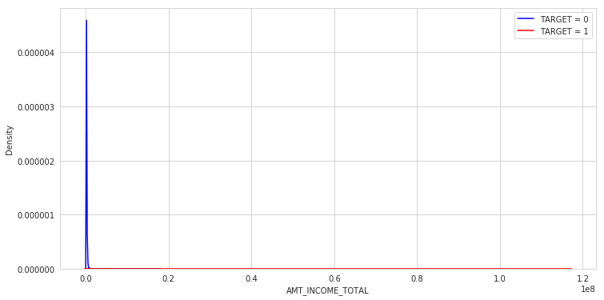

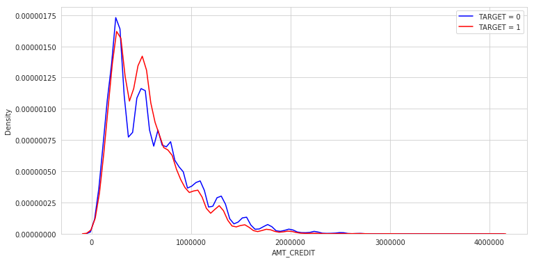

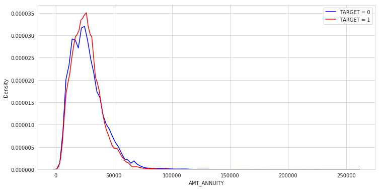

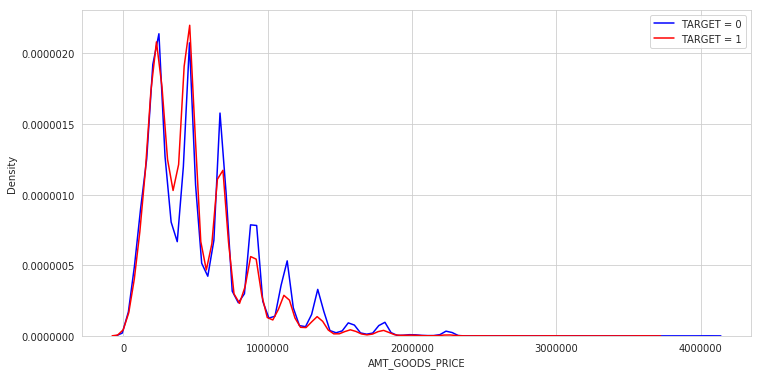

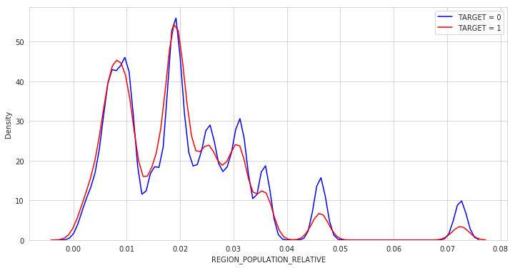

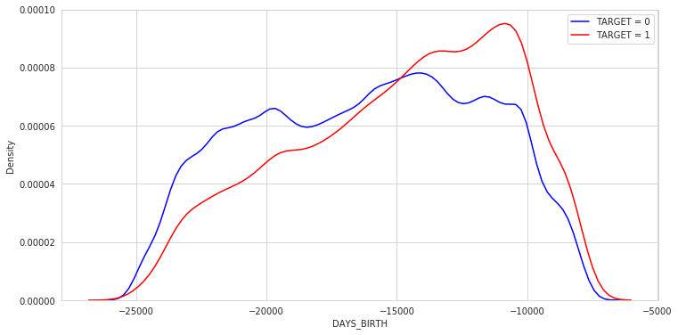

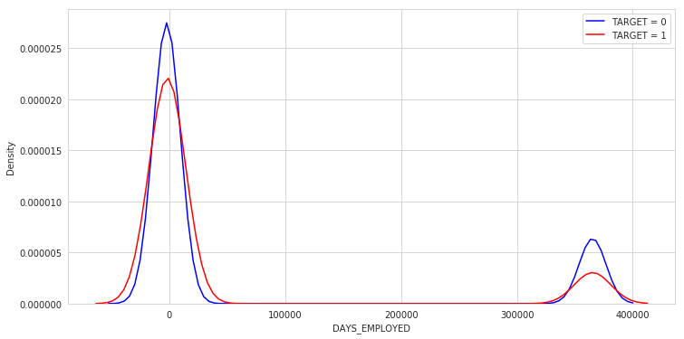

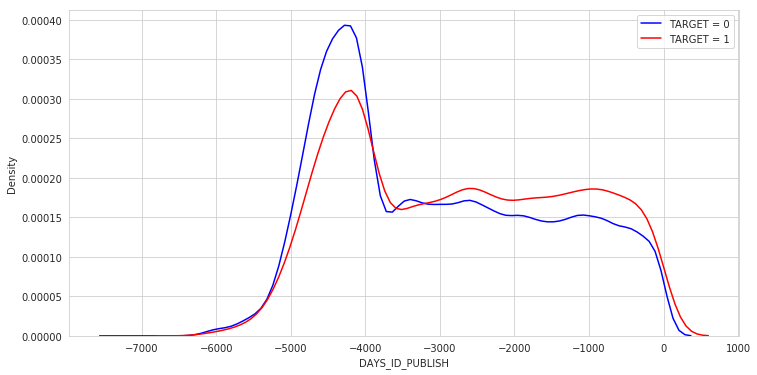

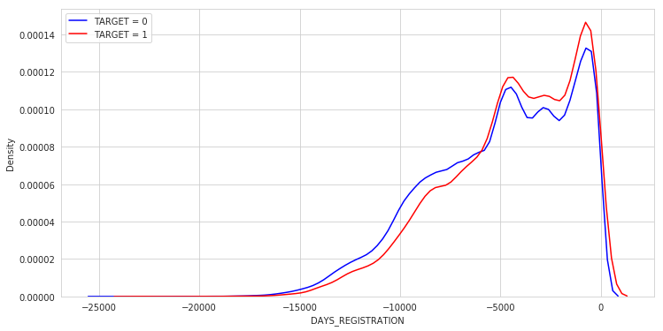

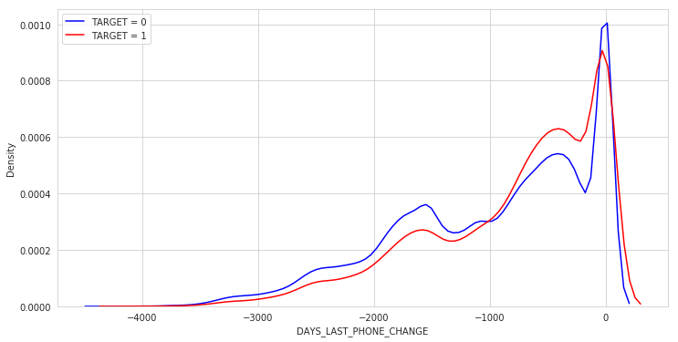

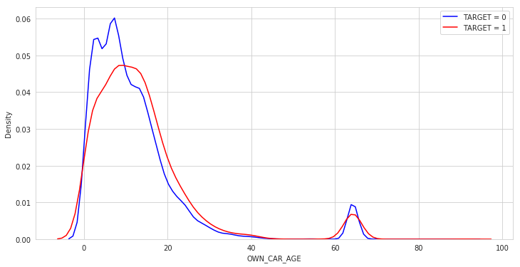

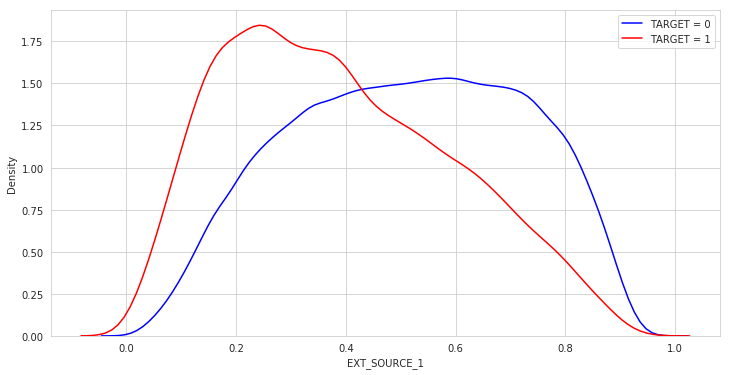

[2 more figures not shown]

```python
for feature in columns_float:
    plot_float_feature(df_application_train, feature, column_target)
```

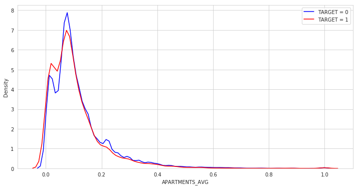

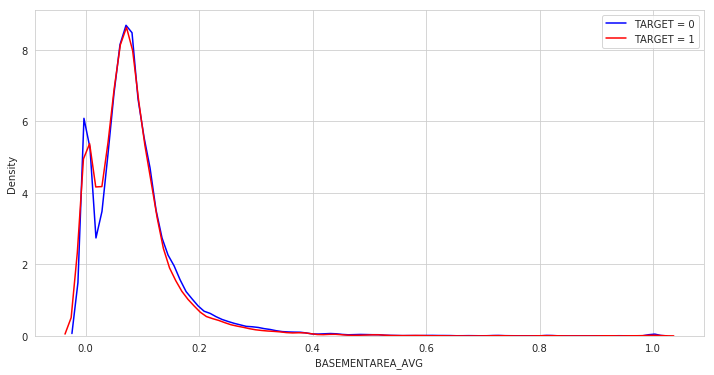

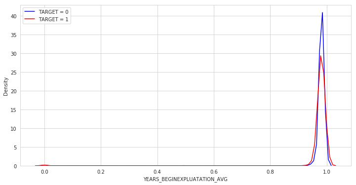

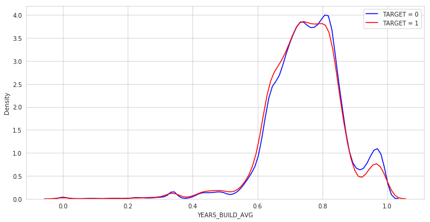

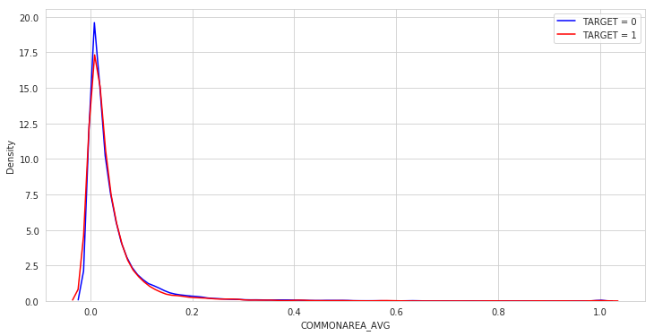

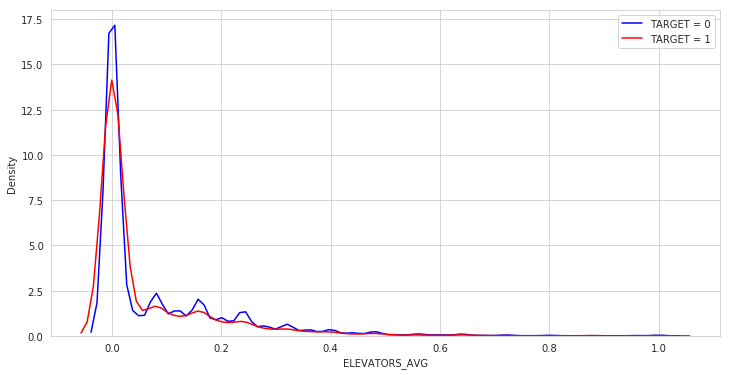

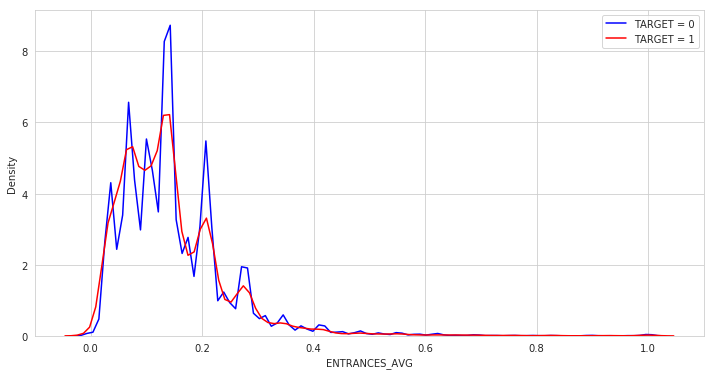

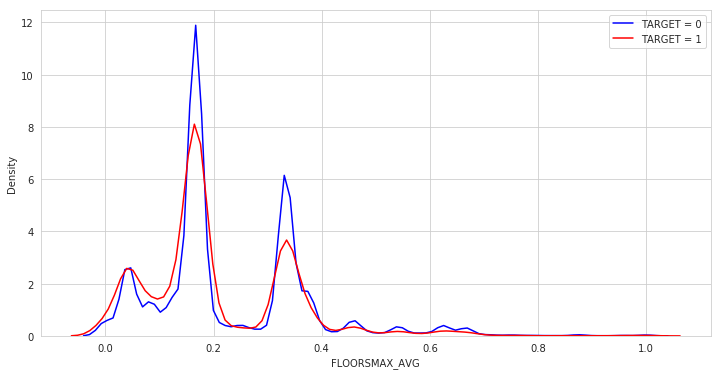

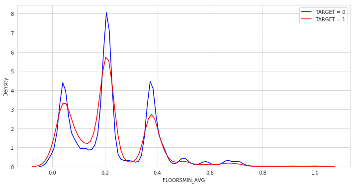

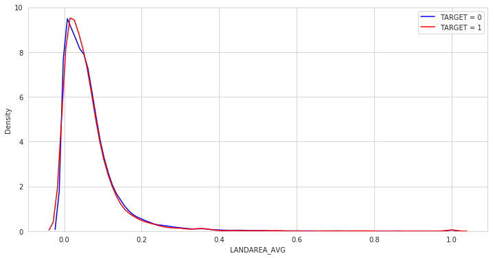

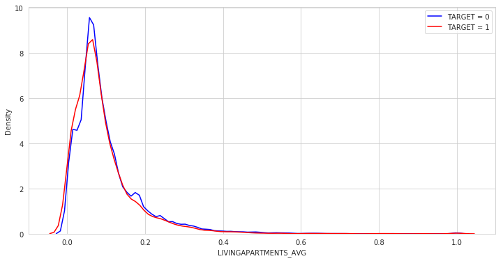

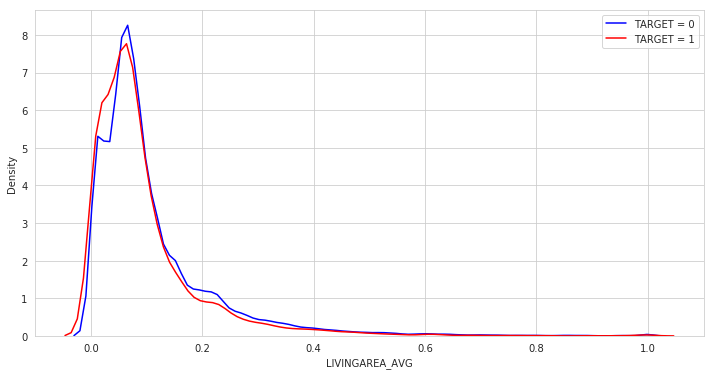

[2 more figures not shown]

```python
for feature in columns_float_avg:
    plot_float_feature(df_application_train, feature, column_target)
```

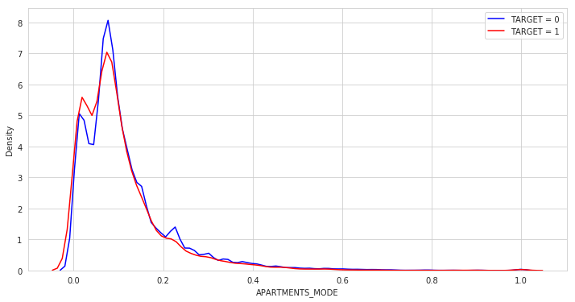

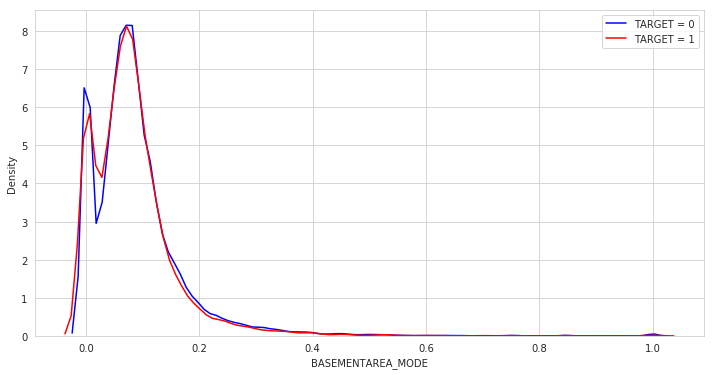

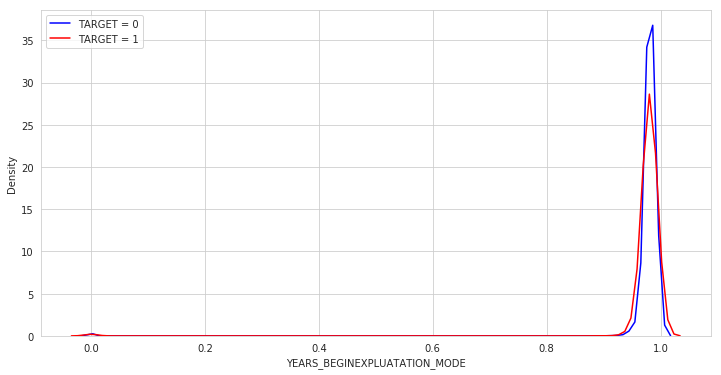

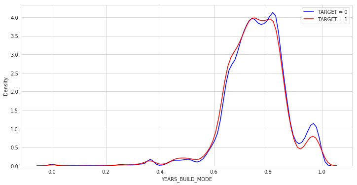

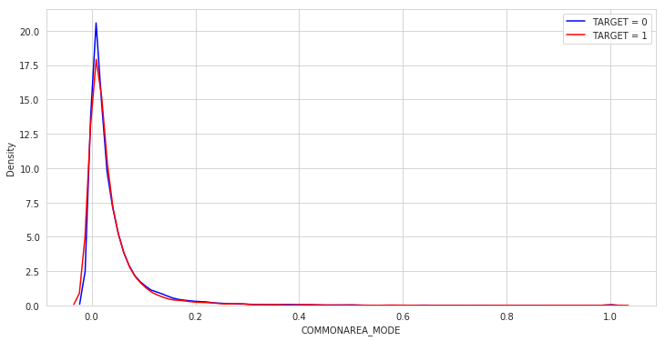

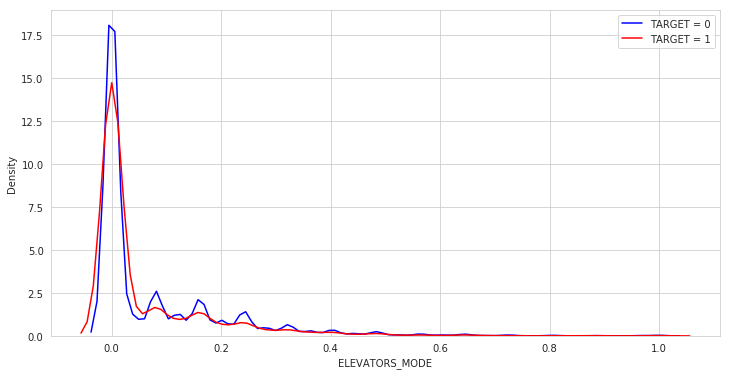

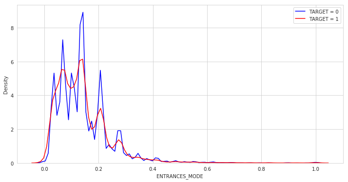

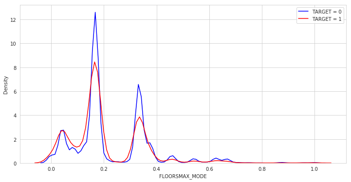

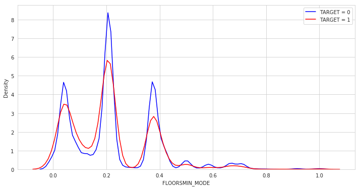

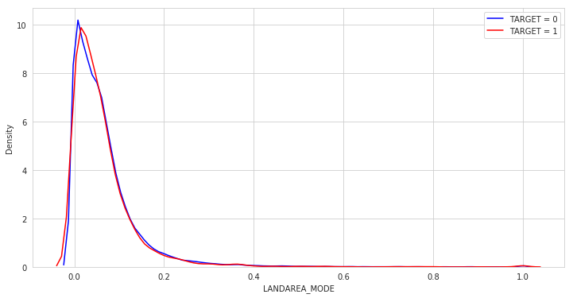

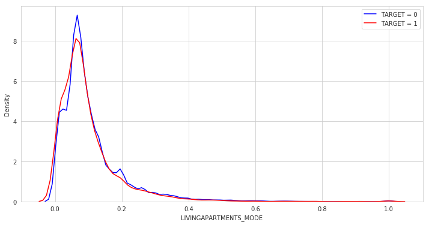

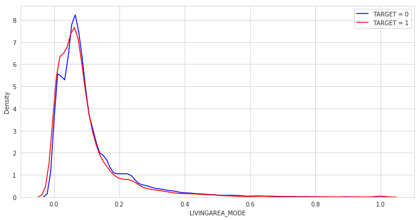

[3 more figures not shown]

```python
for feature in columns_float_mode:
    plot_float_feature(df_application_train, feature, column_target)
```

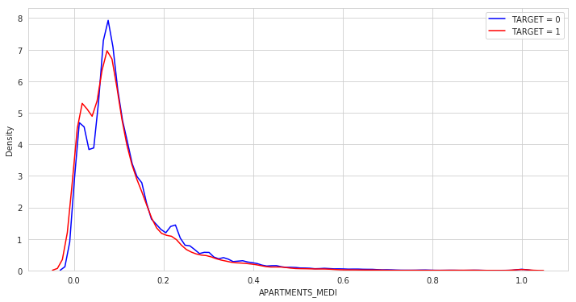

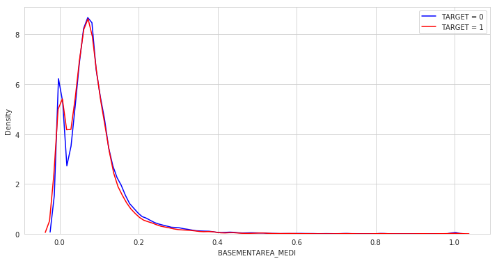

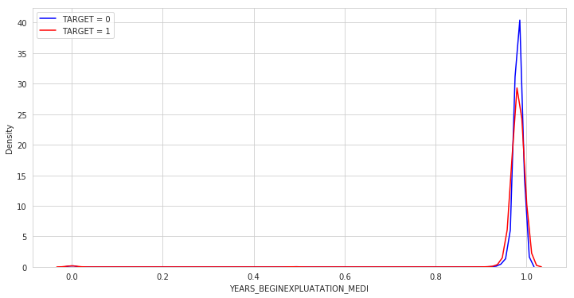

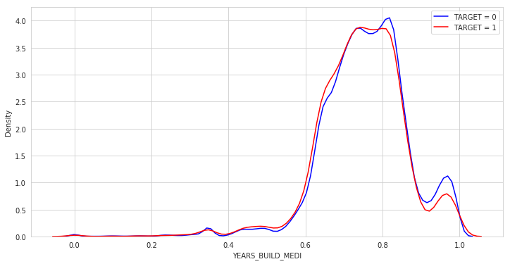

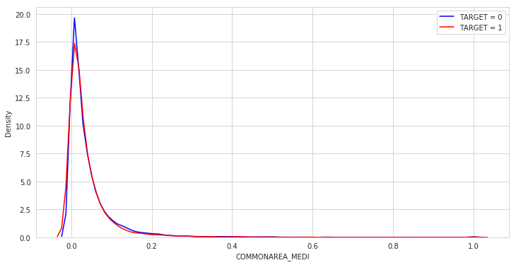

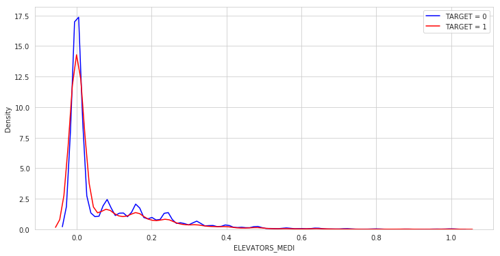

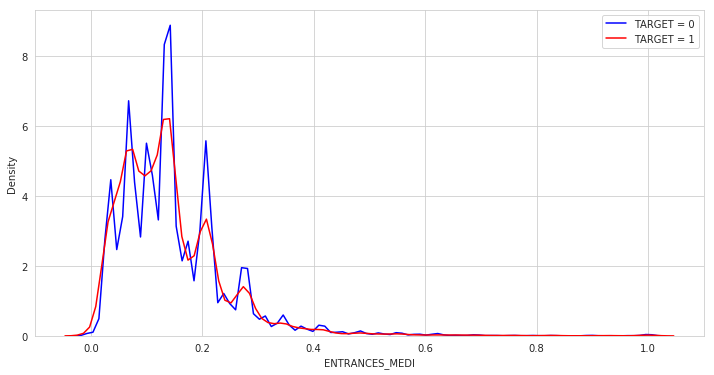

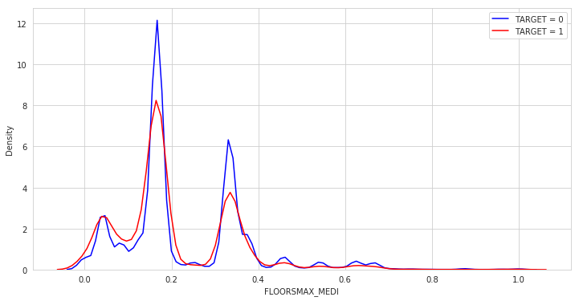

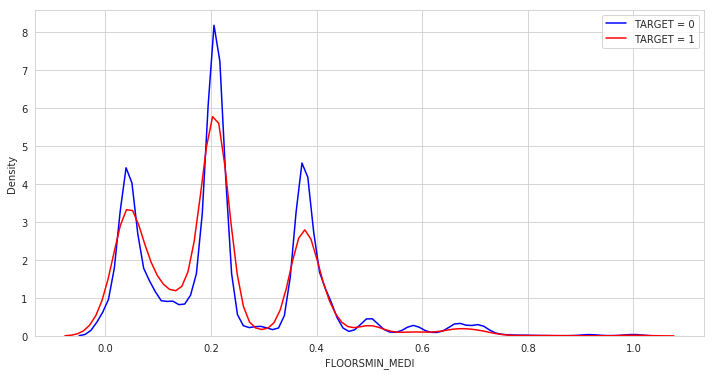

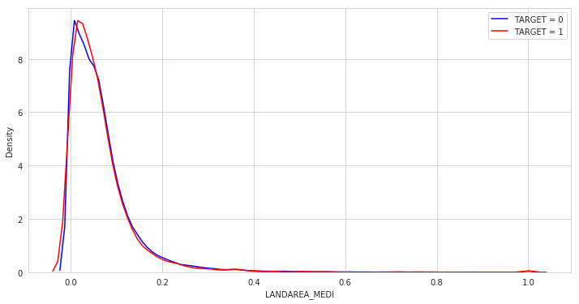

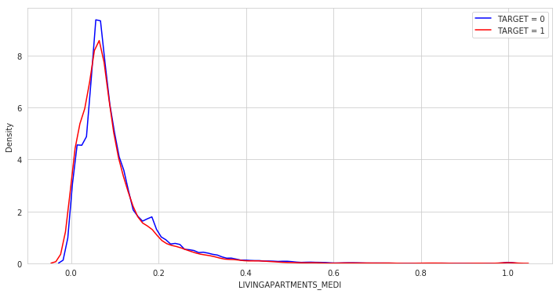

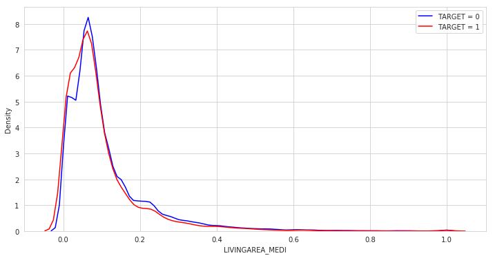

[2 more figures not shown]

```python
for feature in columns_float_medi:
    plot_float_feature(df_application_train, feature, column_target)
```

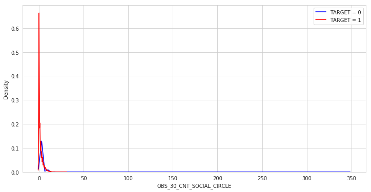

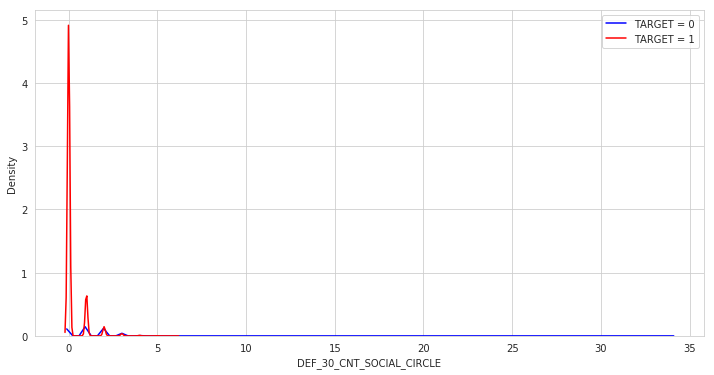

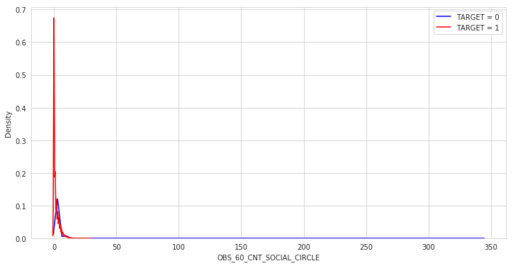

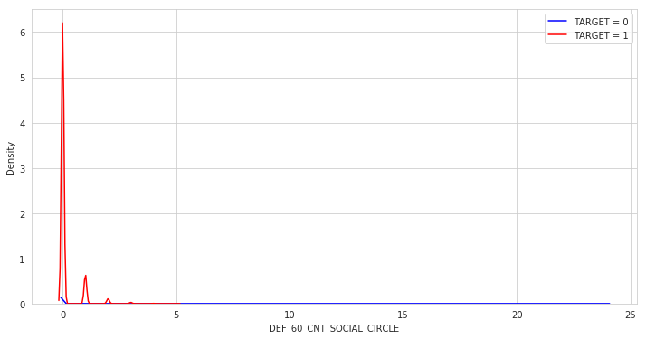

```python
for feature in columns_float_social_circle:
    plot_float_feature(df_application_train, feature, column_target)
```

### Корреляция вещественных признаков

Ну и посмотрим корреляции признаков.

Некоторые предположения подтвердились: **EXT_SOURCE_1, EXT_SOURCE_2, EXT_SOURCE_3** больше остальных коррелируют с таргетом, группы **_AVG, _MODE, _MEDI** сильно коррелируют друг с другом.

```python
corr_matrix = df_application_train[columns_float+columns_float_mode+columns_float_medi+columns_float_avg+\
                                   columns_float_social_circle+[column_target]].corr()
corr_matrix.iplot(kind='heatmap', colorscale='spectral')
```

[interactive chart not shown]

```python
corr_matrix = df_application_train[columns_float+[column_target]].corr()
corr_matrix.iplot(kind='heatmap', colorscale='spectral')
```

[interactive chart not shown]

```python
corr_matrix = df_application_train[columns_float_avg+[column_target]].corr()
corr_matrix.iplot(kind='heatmap', colorscale='spectral')
```

[interactive chart not shown]

```python
corr_matrix = df_application_train[columns_float_mode+[column_target]].corr()
corr_matrix.iplot(kind='heatmap', colorscale='spectral')
```

[interactive chart not shown]

```python
corr_matrix = df_application_train[columns_float_medi+[column_target]].corr()
corr_matrix.iplot(kind='heatmap', colorscale='spectral')
```

[interactive chart not shown]

```python
corr_matrix = df_application_train[columns_float_social_circle+[column_target]].corr()
corr_matrix.iplot(kind='heatmap', colorscale='spectral')
```

[interactive chart not shown]

```python
df_application_train[columns_float].describe().T
```

|  | count | mean | std | min | 25% | 50% | 75% | max |
| --- | --- | --- | --- | --- | --- | --- | --- | --- |
| AMT_INCOME_TOTAL | 307511.0 | 168797.919297 | 237123.146279 | 2.565000e+04 | 112500.000000 | 147150.000000 | 202500.000000 | 1.170000e+08 |
| AMT_CREDIT | 307511.0 | 599025.999706 | 402490.776996 | 4.500000e+04 | 270000.000000 | 513531.000000 | 808650.000000 | 4.050000e+06 |
| AMT_ANNUITY | 307499.0 | 27108.573909 | 14493.737315 | 1.615500e+03 | 16524.000000 | 24903.000000 | 34596.000000 | 2.580255e+05 |
| AMT_GOODS_PRICE | 307233.0 | 538396.207429 | 369446.460540 | 4.050000e+04 | 238500.000000 | 450000.000000 | 679500.000000 | 4.050000e+06 |
| REGION_POPULATION_RELATIVE | 307511.0 | 0.020868 | 0.013831 | 2.900000e-04 | 0.010006 | 0.018850 | 0.028663 | 7.250800e-02 |
| DAYS_BIRTH | 307511.0 | -16036.995067 | 4363.988632 | -2.522900e+04 | -19682.000000 | -15750.000000 | -12413.000000 | -7.489000e+03 |
| DAYS_EMPLOYED | 307511.0 | 63815.045904 | 141275.766519 | -1.791200e+04 | -2760.000000 | -1213.000000 | -289.000000 | 3.652430e+05 |
| DAYS_ID_PUBLISH | 307511.0 | -2994.202373 | 1509.450419 | -7.197000e+03 | -4299.000000 | -3254.000000 | -1720.000000 | 0.000000e+00 |
| DAYS_REGISTRATION | 307511.0 | -4986.120328 | 3522.886321 | -2.467200e+04 | -7479.500000 | -4504.000000 | -2010.000000 | 0.000000e+00 |
| DAYS_LAST_PHONE_CHANGE | 307510.0 | -962.858788 | 826.808487 | -4.292000e+03 | -1570.000000 | -757.000000 | -274.000000 | 0.000000e+00 |
| OWN_CAR_AGE | 104582.0 | 12.061091 | 11.944812 | 0.000000e+00 | 5.000000 | 9.000000 | 15.000000 | 9.100000e+01 |
| EXT_SOURCE_1 | 134133.0 | 0.502130 | 0.211062 | 1.456813e-02 | 0.334007 | 0.505998 | 0.675053 | 9.626928e-01 |
| EXT_SOURCE_2 | 306851.0 | 0.514393 | 0.191060 | 8.173617e-08 | 0.392457 | 0.565961 | 0.663617 | 8.549997e-01 |
| EXT_SOURCE_3 | 246546.0 | 0.510853 | 0.194844 | 5.272652e-04 | 0.370650 | 0.535276 | 0.669057 | 8.960095e-01 |

```python
df_application_train[columns_float_social_circle].describe().T
```

|  | count | mean | std | min | 25% | 50% | 75% | max |
| --- | --- | --- | --- | --- | --- | --- | --- | --- |
| OBS_30_CNT_SOCIAL_CIRCLE | 306490.0 | 1.422245 | 2.400989 | 0.0 | 0.0 | 0.0 | 2.0 | 348.0 |
| DEF_30_CNT_SOCIAL_CIRCLE | 306490.0 | 0.143421 | 0.446698 | 0.0 | 0.0 | 0.0 | 0.0 | 34.0 |
| OBS_60_CNT_SOCIAL_CIRCLE | 306490.0 | 1.405292 | 2.379803 | 0.0 | 0.0 | 0.0 | 2.0 | 344.0 |
| DEF_60_CNT_SOCIAL_CIRCLE | 306490.0 | 0.100049 | 0.362291 | 0.0 | 0.0 | 0.0 | 0.0 | 24.0 |

```python
df_application_train[columns_float_mode].describe().T
```

|  | count | mean | std | min | 25% | 50% | 75% | max |
| --- | --- | --- | --- | --- | --- | --- | --- | --- |
| APARTMENTS_MODE | 151450.0 | 0.114231 | 0.107936 | 0.0 | 0.0525 | 0.0840 | 0.1439 | 1.0 |
| BASEMENTAREA_MODE | 127568.0 | 0.087543 | 0.084307 | 0.0 | 0.0407 | 0.0746 | 0.1124 | 1.0 |
| YEARS_BEGINEXPLUATATION_MODE | 157504.0 | 0.977065 | 0.064575 | 0.0 | 0.9767 | 0.9816 | 0.9866 | 1.0 |
| YEARS_BUILD_MODE | 103023.0 | 0.759637 | 0.110111 | 0.0 | 0.6994 | 0.7648 | 0.8236 | 1.0 |
| COMMONAREA_MODE | 92646.0 | 0.042553 | 0.074445 | 0.0 | 0.0072 | 0.0190 | 0.0490 | 1.0 |
| ELEVATORS_MODE | 143620.0 | 0.074490 | 0.132256 | 0.0 | 0.0000 | 0.0000 | 0.1208 | 1.0 |
| ENTRANCES_MODE | 152683.0 | 0.145193 | 0.100977 | 0.0 | 0.0690 | 0.1379 | 0.2069 | 1.0 |
| FLOORSMAX_MODE | 154491.0 | 0.222315 | 0.143709 | 0.0 | 0.1667 | 0.1667 | 0.3333 | 1.0 |
| FLOORSMIN_MODE | 98869.0 | 0.228058 | 0.161160 | 0.0 | 0.0833 | 0.2083 | 0.3750 | 1.0 |
| LANDAREA_MODE | 124921.0 | 0.064958 | 0.081750 | 0.0 | 0.0166 | 0.0458 | 0.0841 | 1.0 |
| LIVINGAPARTMENTS_MODE | 97312.0 | 0.105645 | 0.097880 | 0.0 | 0.0542 | 0.0771 | 0.1313 | 1.0 |
| LIVINGAREA_MODE | 153161.0 | 0.105975 | 0.111845 | 0.0 | 0.0427 | 0.0731 | 0.1252 | 1.0 |
| NONLIVINGAPARTMENTS_MODE | 93997.0 | 0.008076 | 0.046276 | 0.0 | 0.0000 | 0.0000 | 0.0039 | 1.0 |
| NONLIVINGAREA_MODE | 137829.0 | 0.027022 | 0.070254 | 0.0 | 0.0000 | 0.0011 | 0.0231 | 1.0 |
| TOTALAREA_MODE | 159080.0 | 0.102547 | 0.107462 | 0.0 | 0.0412 | 0.0688 | 0.1276 | 1.0 |